# 21082022 Question 3

H MacGinty

June 2023

### Abstract

This report provides an overview of the two institutional legends in music history, Coldplay and Metallica. The report ends off by giving some insight into other popular contemporary music.

# Introduction

Coldplay and Metallica are two of the most famous bands of all time.

This report examines major trends in popularity, danceability and energy in their respective albums.

# Coldplay

Coldplay is examined first. Albums are filtered to exclude any live or tour versions.

By looking at danceability, it can be seen that “Ghost Stories” has the highest danceability. People find it difficult to dance to “Love in Tokyo”.

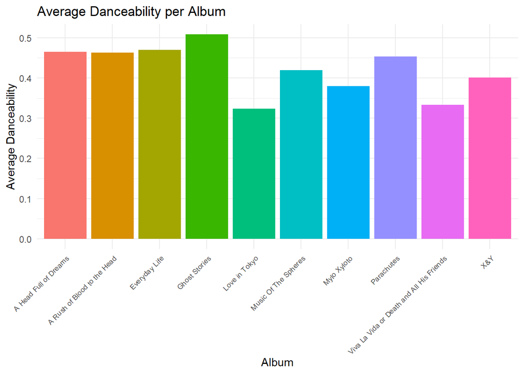

When looking at popularity per album, it is a close call between Parachutes, A Rush of Blood to the Head, and A Head Full of Dreams. Love in Tokyo is the least popular album.

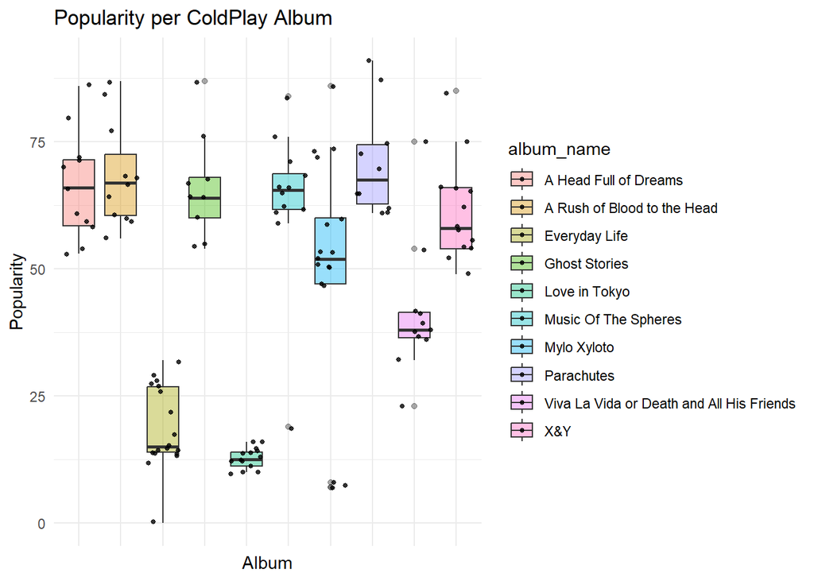

```
## # A tibble: 1 × 1
##    Corr
##   <dbl>
## 1 0.361
```

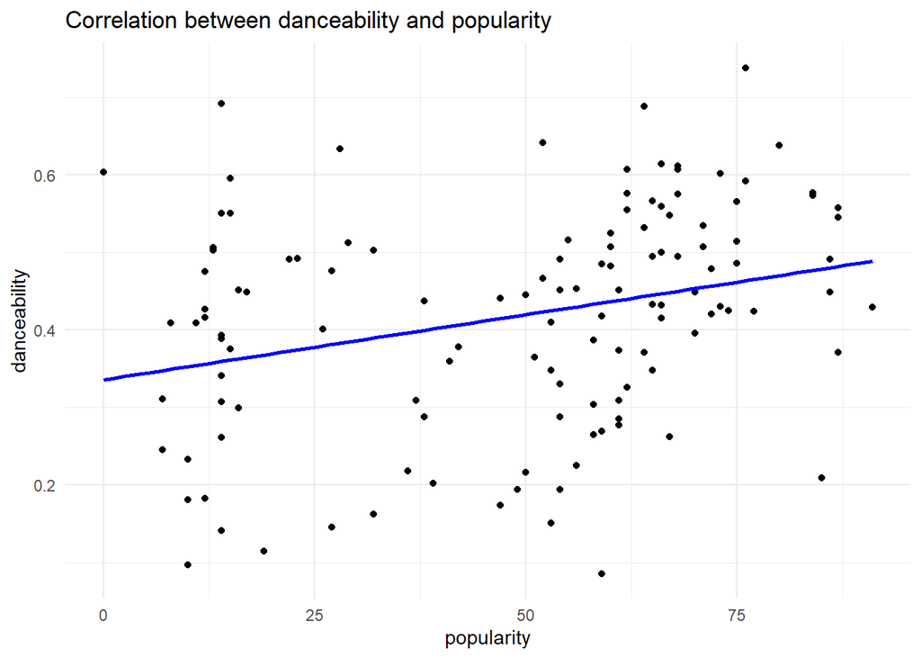

Table 1: Correlation between popularity and danceability for each Coldplay album

|  | album_name | Correlation |
| --- | --- | --- |
| 1 | A Head Full of Dreams | 0.7454545 |
| 2 | A Rush of Blood to the Head | 0.5056961 |
| 3 | Everyday Life | -0.0130624 |
| 4 | Ghost Stories | 0.6025157 |
| 5 | Love in Tokyo | 0.4325984 |
| 6 | Music Of The Spheres | 0.7157939 |
| 7 | Mylo Xyloto | 0.4864880 |
| 8 | Parachutes | 0.2439070 |
| 9 | Viva La Vida or Death and All His Friends | 0.2687934 |
| 10 | X&Y | 0.2620712 |

Comparing the studio version and live version of “Ghost Stories”, the energy level in the live version is much higher. This implies that Coldplay is much better live.

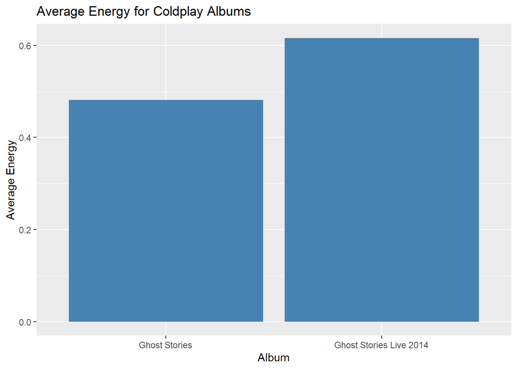

# Metallica

Averaging danceability per album for Metallica, we can see that their classic “Metallica” album score the highest danceability.

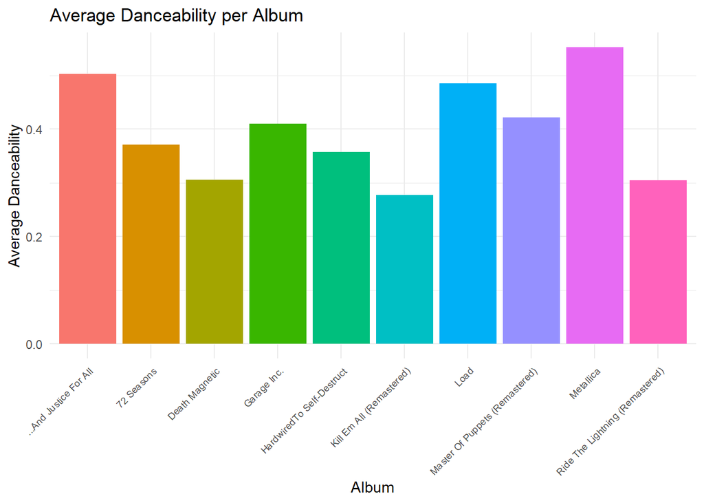

Interestingly, the most popular album on average is 72 Seasons. It is followed by Metallica, which has the widest ranging popularity scores among listeners.

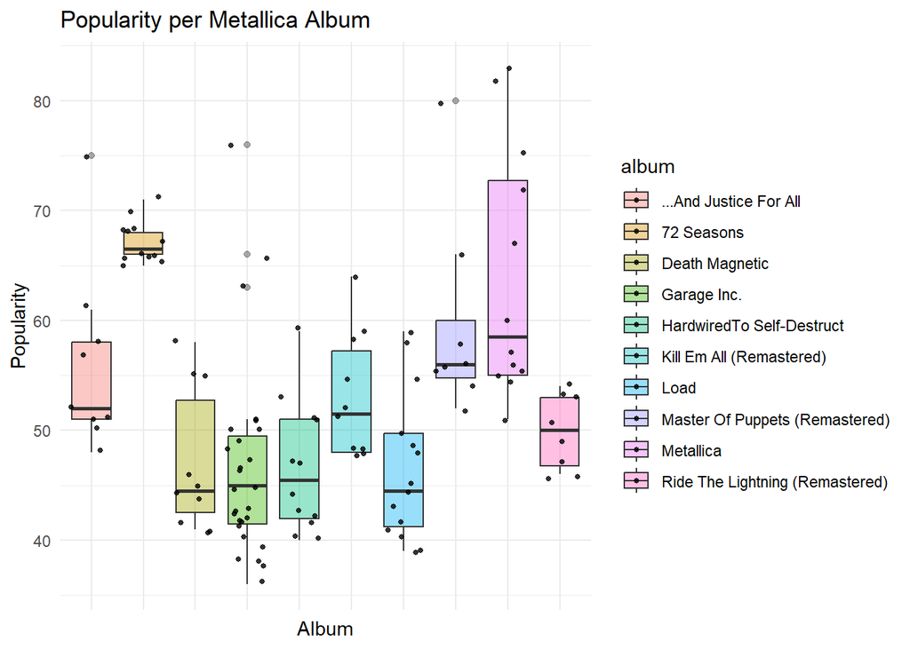

Similar to that of coldplay, Metallica has a positive correlation between danceability and popularity. The breakdown among albums is also tabled below.

Table 2: Correlation between popularity and danceability for each Metallica album

|  | album | Correlation |
| --- | --- | --- |
| 1 | …And Justice For All | 0.1087876 |
| 2 | 72 Seasons | -0.2370698 |
| 3 | Death Magnetic | 0.1590281 |
| 4 | Garage Inc. | 0.2308643 |
| 5 | HardwiredTo Self-Destruct | -0.2535274 |
| 6 | Kill Em All (Remastered) | 0.5127504 |
| 7 | Load | -0.1584159 |
| 8 | Master Of Puppets (Remastered) | 0.7425283 |
| 9 | Metallica | 0.3852896 |
| 10 | Ride The Lightning (Remastered) | 0.1807360 |

```
##        Corr
## 1 0.1431962
```

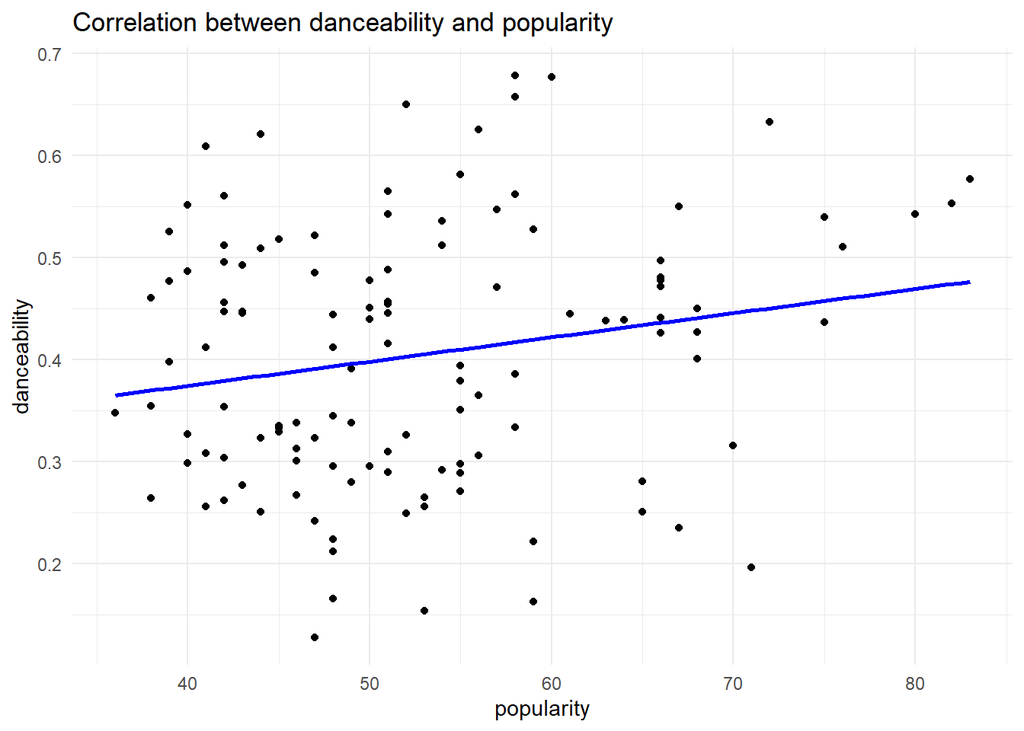

When comparing the studio and live version for Some Kind of Monster, the average energy is the same. This show Metallica puts in just as much effort at the shows as in the studio albums. Legends!

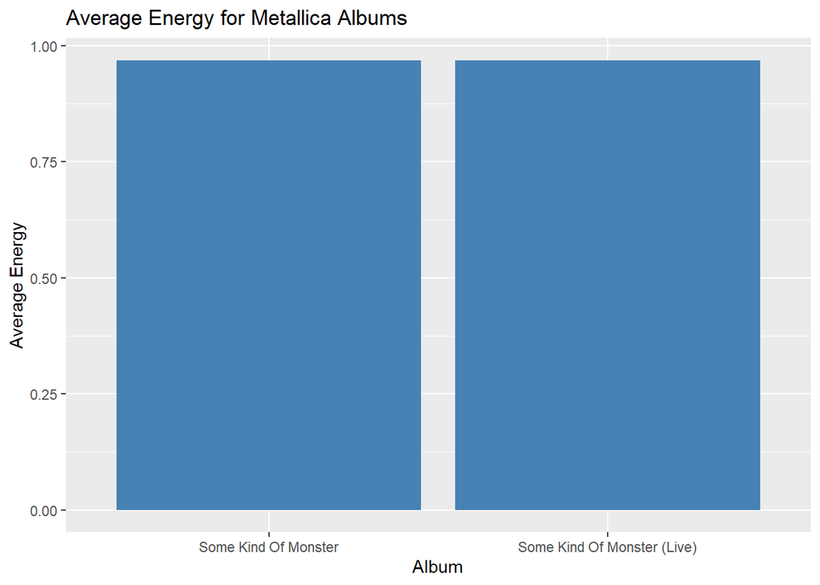

# Broad Music Trends

When looking more broadly at the music scene, the 10 most danceable songs on Spotify are listed below. The number one most danceable song in recent history is Leave Me Now by Herbert, receiving a danceability score of 0.986.

Table 3: Top 10 Most Danceable Songs

|  | name | artist | danceability |
| --- | --- | --- | --- |
| 1 | Leave Me Now | Herbert | 0.986 |
| 2 | Go Girl | Pitbull | 0.985 |
| 3 | Funky Cold Medina | Tone-Lōc | 0.984 |
| 4 | State of Shock | The Jacksons | 0.982 |
| 5 | Teachers | Daft Punk | 0.980 |
| 6 | Give It To Me | Timbaland | 0.975 |
| 7 | Ice Ice Baby (Radio Edit) | Vanilla Ice | 0.975 |
| 8 | Tape Song | The Kills | 0.974 |
| 9 | Heavy Machinery | Scuba | 0.973 |
| 10 | Long Shot Kick De Bucket | The Pioneers | 0.971 |